# Data Analysis ... lift-off for Jupyter

### Sympy - Illustrating the Taylor Series

```python
%matplotlib inline
import numpy as np
import matplotlib.pyplot as plt

# You can change the default figure size to be a bit larger if you want,
# uncomment the next line for that:
#plt.rc('figure', figsize=(10, 6))
```

```python
def plot_taylor_approximations(func, x0=None, orders=(2, 4), xrange=(0,1), yrange=None, npts=200):
    """Plot the Taylor series approximations to a function at various orders.

    Parameters
    ----------
    func : a sympy function
    x0 : float
      Origin of the Taylor series expansion.  If not given, x0=xrange[0].
    orders : list
      List of integers with the orders of Taylor series to show.  Default is (2, 4).
    xrange : 2-tuple or array.
      Either an (xmin, xmax) tuple indicating the x range for the plot (default is (0, 1)),
      or the actual array of values to use.
    yrange : 2-tuple
      (ymin, ymax) tuple indicating the y range for the plot.  If not given,
      the full range of values will be automatically used.
    npts : int
      Number of points to sample the x range with.  Default is 200.
    """
    if not callable(func):
        raise ValueError('func must be callable')
    if isinstance(xrange, (list, tuple)):
        x = np.linspace(float(xrange[0]), float(xrange[1]), npts)
    else:
        x = xrange
    if x0 is None: x0 = x[0]
    xs = sym.Symbol('x')
    # Make a numpy-callable form of the original function for plotting
    fx = func(xs)
    f = sym.lambdify(xs, fx, modules=['numpy'])
    # We could use latex(fx) instead of str(), but matploblib gets confused
    # with some of the (valid) latex constructs sympy emits.  So we play it safe.
    plt.plot(x, f(x), label=str(fx), lw=2)
    # Build the Taylor approximations, plotting as we go
    apps = {}
    for order in orders:
        app = fx.series(xs, x0, n=order).removeO()
        apps[order] = app
        # Must be careful here: if the approximation is a constant, we can't
        # blindly use lambdify as it won't do the right thing.  In that case,
        # evaluate the number as a float and fill the y array with that value.
        if isinstance(app, sym.numbers.Number):
            y = np.zeros_like(x)
            y.fill(app.evalf())
        else:
            fa = sym.lambdify(xs, app, modules=['numpy'])
            y = fa(x)
        tex = sym.latex(app).replace('$', '')
        plt.plot(x, y, label=r'$n=%s:\, %s$' % (order, tex) )

    # Plot refinements
    if yrange is not None:
        plt.ylim(*yrange)
    plt.grid()
    plt.legend(loc='best').get_frame().set_alpha(0.8)
```

With this function defined we can now use it to solve any expression

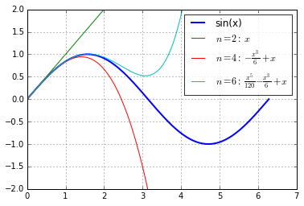

```python
plot_taylor_approximations(sin, 0, [2, 4, 6], (0, 2*pi), (-2,2))
```

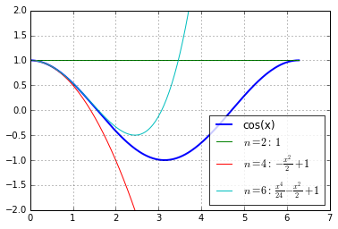

```python
plot_taylor_approximations(cos, 0, [2, 4, 6], (0, 2*pi), (-2,2))
```

```python
# This shows easily how a Taylor series is useless beyond its convergence radius, illustrated by a simple function that has singularities on the real axis:
```

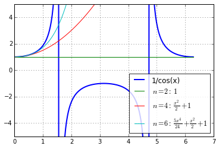

```python
# For an expression made from elementary functions, we must first make it into
# a callable function, the simplest way is to use the Python lambda construct.
plot_taylor_approximations(lambda x: 1/cos(x), 0, [2,4,6], (0, 2*pi), (-5,5))
```

### Plotting

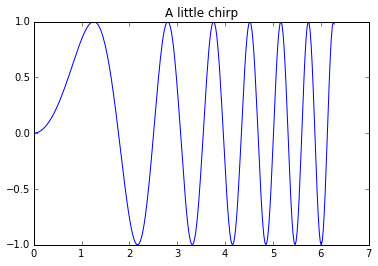

```python
%matplotlib inline

import numpy as np
import matplotlib.pyplot as plt

x = np.linspace(0, 2*np.pi, 300)
y = np.sin(x**2)
plt.plot(x, y)
plt.title("A little chirp")
fig = plt.gcf()
```

### Plotting with interaction

```
None
```

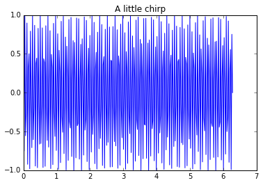

```python
%matplotlib inline
import numpy as np; import matplotlib.pyplot as plt; from __future__ import print_function; from IPython.html.widgets import interact, interactive, fixed; from IPython.html import widgets
def myplot(max1, max2):
    x = np.linspace(0, 2*np.pi, max2); y = np.sin(max1 * x)
    plt.plot(x, y); plt.title("A little chirp")
    fig = plt.gcf()
interact(myplot, max1=300, max2=300);
```

IPython/Jupyter - History Guided tour - What If it was code? What if - we could execute the JavaScript below?

```python
%%javascript

console.log('hi there - from Jupyter (well IPython actually)!');
alert('hi there - the possibilities are endless - respect your DOM!!');
```

```python
%%svg     <!-- svg from http://tutorials.jenkov.com/svg/svg-animation.html -->

<svg xmlns="http://www.w3.org/2000/svg"
    xmlns:xlink="http://www.w3.org/1999/xlink">

    <rect x="10" y="10" height="110" width="110"
         style="stroke:#ff00ff; fill: #00ffff">
        <animateTransform
            attributeName="transform"
            begin="0s"
            dur="20s"
            type="rotate"
            from="0 60 60"
            to="360 60 60"
            repeatCount="indefinite"
        />
    </rect>
</svg>
```

```python
from IPython.display import HTML

s = """<table>
<tr>
<th>Header 1</th>
<th>Header 2</th>
</tr>
<tr>
<td>row 1, cell 1</td>
<td>row 1, cell 2</td>
</tr>
<tr>
<td>row 2, cell 1</td>
<td>row 2, cell 2</td>
</tr>
</table>"""

h = HTML(s)
display(h)
```

```python
from IPython.display import YouTubeVideo
YouTubeVideo("rl5DaFbLc60")
# But that's a bit small
#YouTubeVideo?
#YouTubeVideo("rl5DaFbLc60", width=1200, height=800)
```

```python
from IPython.display import IFrame
IFrame('http://mybinder.org', 800, 600)
```

## D3 Demo

```python
%%writefile f1.template
<!DOCTYPE html>
<!--
      ************************************************************************
      *** HTML template to be embedded  in o/p cell for D3 demo **************
      ************************************************************************
-->
<html>
    <meta http-equiv="Content-Type" content="text/html;charset=utf-8"/>
    <script type="text/javascript" src="http://mbostock.github.io/d3/talk/20111018/d3/d3.js"></script>
    <script type="text/javascript" src="http://mbostock.github.io/d3/talk/20111018/d3/d3.geom.js"></script>
    <script type="text/javascript" src="http://mbostock.github.io/d3/talk/20111018/d3/d3.layout.js"></script>
    <style type="text/css">

circle {
  stroke: #000;
  stroke-opacity: .5;
}

    </style>
  <body>
    <div id="body">
    <script type="text/javascript">

var w = {width},
    h = {height};

var nodes = d3.range({ball_count}).map(function() { return {radius: Math.random() * {rad_fac} + {rad_min}}; }),
    color = d3.scale.category10();

var force = d3.layout.force()
    .gravity(0.1)
    .charge(function(d, i) { return i ? 0 : -2000; })
    .nodes(nodes)
    .size([w, h]);

var root = nodes[0];
root.radius = 0;
root.fixed = true;

force.start();

var svg = d3.select("#body").append("svg:svg")
    .attr("width", w)
    .attr("height", h);

svg.selectAll("circle")
    .data(nodes.slice(1))
  .enter().append("svg:circle")
    .attr("r", function(d) { return d.radius - 2; })
    .style("fill", function(d, i) { return color(i % {color_count}); });

force.on("tick", function(e) {
  var q = d3.geom.quadtree(nodes),
      i = 0,
      n = nodes.length;

  while (++i < n) {
    q.visit(collide(nodes[i]));
  }

  svg.selectAll("circle")
      .attr("cx", function(d) { return d.x; })
      .attr("cy", function(d) { return d.y; });
});

svg.on("mousemove", function() {
  var p1 = d3.svg.mouse(this);
  root.px = p1[0];
  root.py = p1[1];
  force.resume();
});

function collide(node) {
  var r = node.radius + 16,
      nx1 = node.x - r,
      nx2 = node.x + r,
      ny1 = node.y - r,
      ny2 = node.y + r;
  return function(quad, x1, y1, x2, y2) {
    if (quad.point && (quad.point !== node)) {
      var x = node.x - quad.point.x,
          y = node.y - quad.point.y,
          l = Math.sqrt(x * x + y * y),
          r = node.radius + quad.point.radius;
      if (l < r) {
        l = (l - r) / l * .5;
        node.x -= x *= l;
        node.y -= y *= l;
        quad.point.x += x;
        quad.point.y += y;
      }
    }
    return x1 > nx2
        || x2 < nx1
        || y1 > ny2
        || y2 < ny1;
  };
}

    </script>
  </body>
</html>
```

```
Overwriting f1.template
```

```python
from IPython.display import display
from IPython.display import HTML
import IPython.core.display as di # Example: di.display_html('<h3>%s:</h3>' % str, raw=True)

# This code is to embed the above html template

from IPython.display import IFrame
import re

def replace_all(txt,d):
    rep = dict((re.escape('{'+k+'}'), str(v)) for k, v in d.items())
    pattern = re.compile("|".join(rep.keys()))
    return pattern.sub(lambda m: rep[re.escape(m.group(0))], txt)

count=0
def serve_html(s,w,h):
    import os
    global count
    count+=1
    fn= '__tmp'+str(os.getpid())+'_'+str(count)+'.html'
    with open(fn,'w') as f:
        f.write(s)
    return IFrame('files/'+fn,w,h)

def f1(w=500,h=400,ball_count=150,rad_min=2,rad_fac=11,color_count=3):
    d={
       'width'      :w,
       'height'     :h,
       'ball_count' :ball_count,
       'rad_min'    :rad_min,
       'rad_fac'    :rad_fac,
       'color_count':color_count
       }
    with open('f1.template','r') as f:
        s=f.read()
    s= replace_all(s,d)
    return serve_html(s,w+30,h+30)
```

```python
from IPython.display import display
from IPython.display import HTML
import IPython.core.display as di # Example: di.display_html('<h3>%s:</h3>' % str, raw=True)

# This line will hide code by default when the notebook is exported as HTML
di.display_html('<script>jQuery(function() {if (jQuery("body.notebook_app").length == 0) { jQuery(".input_area").toggle(); jQuery(".prompt").toggle();}});</script>', raw=True)

# This line will add a button to toggle visibility of code blocks, for use with the HTML export version
di.display_html('''<button onclick="jQuery('.input_area').toggle(); jQuery('.prompt').toggle();">Toggle code</button>''', raw=True)

# The demo code ....
f1(ball_count=100, color_count=17, rad_fac=10, rad_min=3, w=800)
```

[interactive chart not shown]

# IPython/Jupyter

## what they are, how they’re used?

- Growing eco-system
- Data Scientists
- Presentations
- Blogging
- Publishing
- Education

# Ecosystem

Openness enabling ecosystem (and even competition?)  
Sponsors

- Colab/Google -> JupyterDrive
- Rackspace: Hosting nbviewer
- Microsoft: Azure Hosting / VStudio Tools
- github: Rendering
- Authorea
- Quantopian
- O'Reilly
- IBM
  - Contributing
  - BlueMix

### Competition

- Apache Zeppelin (incubating) - Scala is default language, but polyglot
- Lots of commercial products - you tell me
  - Mathlab (+/-)
  - Sage
  - ...

### Contributing

- repos ..
  - core projects
    - Low hanging fruit [search on github](https://github.com/search?utf8=%E2%9C%93&q=is%3Aopen+is%3Aissue+is%3Asprint-friendly+user%3Aipython+user%3Ajupyer+user%3Aphosphorjs+user%3Anteract)
  - [Extensions](https://github.com/ipython-contrib/IPython-notebook-extensions)
  - kernels
- notebooks ..
- blogging ..
- testing ...
- evangelising
  - pyconfr
  - mixit
  - ...

## References

- Jupyter.org
- TryJupyter.org
- github.com/IPython, github.com/Jupyter
- Jupyter Blog
- Read the docs
- Kernels
- Google Groups
- Tutorials:
  - ipython-in-depth (youtube) (github)
  - ...
  - ...
- Apache Zeppelin (competitor) (youtube) (github)

### IPython/Jupyter - usage - Stocks Analysis (Quantopian)

[quantopian](https://www.quantopian.com/research/survey)

### IPython/Jupyter - usage - Nature Publication

```python
from IPython.display import IFrame
IFrame('http://www.nature.com/news/interactive-notebooks-sharing-the-code-1.16261', 800, 600)
```

[interactive chart not shown]

### IPython/Jupyter - usage - Galleries of Notebooks

[IPython Gallery](https://github.com/ipython/ipython/wiki/A-gallery-of-interesting-IPython-Notebooks) - rendered by github  
[nbviewer.ipython.org](http://nbviewer.ipython.org/)  
[try.jupyter.org](https://try.jupyter.org/)

### MOOCs using IPython / Jupyter

| MOOC | Site |  |
| --- | --- | --- |
| Python, les Fondamentaux | FUN |  |
| High Perf. Computing | Coursera |  |
| Intro to Apache Spark | Edx |  |
| Scalable Machine Learning | Edx |  |
| Algorithms for DNA Sequencing | Coursera |  |
| Numerical MOOC | OpenEdx.GWU |  |
| Exploratory Data Analysis | Coursera(*) |  |

### Books about IPython / Jupyter

| Title |  |
| --- | --- |
| [The Jupyter GitBook](https://www.gitbook.com/book/carreau/jupyter-book/details) |  |
| [Cyrille Rossant](http://cyrille.rossant.net/books/) Learning IPython for Interactive Computing & Data Visualization |  |
| [Cyrille Rossant](http://cyrille.rossant.net/books/) IPython Interactive Computing & Visualization Cookbook |  |

#### Books Integrating IPython - Springer

Published an electronic book based on IPython notebook

```python
from IPython.display import IFrame
IFrame('http://www.springer.com/us/book/9783319013411', 800, 600)
```

[interactive chart not shown]

#### Books - Created using IPython

OReilly - Mining the Social Web

```python
from IPython.display import IFrame
IFrame('http://shop.oreilly.com/product/0636920030195.do', 800, 600)
```

# Interaction

```python
from __future__ import print_function
from IPython.html.widgets import interact, interactive, fixed
from IPython.html import widgets

def f(x):
    print(x)

interact(f, x=10);
```

```
10
```

```
None
```

```python
interact(f, x=True);
```

```
True
```

```
None
```

```python
interact(f, x='Hi there!');
```

```
Hi there!
```

```
None
```

```python
@interact(x=True, y=1.0)
def g(x, y):
    print(x, y)
```

```
True 1.0
```

```
None
```

```python
def h(p, q):
    print(p, q)

interact(h, p=5, q=fixed(20));
```

```
5 20
```

```
None
```

```python
interact(f, x=widgets.IntSlider(min=-10,max=30,step=4,value=10));
```

```
10
```

```
None
```

```python
@interact(x=(0.0,20.0,0.5))
def h(x=5.5):
    print(x)
```

```
5.5
```

```
None
```

```python
interact(f, x=('apples','oranges'));
```

```
apples
```

```
None
```

```python
interact(f, x={'one': 10, 'two': 20});
```

```
20
```

```
None
```

### We can display images

### But what about the Code of Conduct?

[figure not shown]

```python
from IPython.display import Image
Image(filename="../images/Ours_a_poil.jpg", height=200, width=200)
```